# Introduction to DECODE

```r
# Paths work when the knitting/interactive root is either vignettes_prompt/ or the repo root.
vignette_dir <- if (file.exists(file.path("sim_data", "mutation_table.csv"))) {
    "."
} else if (file.exists(file.path("vignettes_prompt", "sim_data", "mutation_table.csv"))) {
    "vignettes_prompt"
} else {
    stop(
        "Cannot find sim_data/mutation_table.csv. ",
        "Set the working directory to vignettes_prompt/ (recommended) or the DECODE repo root."
    )
}

# Load DECODE after installation:
# devtools::install_github("dinhngockhanh/DECODE")
# library(DECODE)

# Or source the R scripts from a local clone of the repository:
r_dir <- file.path(vignette_dir, "..", "R")
if (dir.exists(r_dir)) {
    r_files <- list.files(r_dir, pattern = "[.]r$|[.]R$", full.names = TRUE)
    invisible(lapply(r_files, source))
}

set.seed(1)
options(max.print = 100)

sample_id <- "example_sample"
data_dir <- file.path(vignette_dir, "sim_data")
output_dir <- file.path(vignette_dir, "DECODE_results")
if (!dir.exists(output_dir)) dir.create(output_dir, recursive = TRUE)
```

# Introduction

DECODE (Deciphering Cancer Origin from DNA Evolution) deconvolves bulk tumor mutations into a neutral tail and one or more mutation clusters based on their Variant Allele Frequencies (VAFs). The algorithm corrects for sample-specific sequencing coverage and mutation-calling biases when building the Site Frequency Spectrum (SFS).

This vignette walks through a complete hands-on workflow:

1. Prepare a mutation table and a copy-number segment file (Section 1).
2. Annotate each mutation with its local copy number (Section 2).
3. Retain diploid loci (`nMajor = 1`, `nMinor = 1`) and run `DECODE()` (Sections 3–4).
4. Save the `DECODE_result` object (Section 5).
5. Generate diagnostic plots (Section 6).
6. Extract key biological parameters: number of clusters, purity, CCF, and mutation burden (Section 7).
7. Compute `normalized_VAF`, estimate multiplicity (e.g. with GRITIC), and assign mutations to DECODE components (Section 8).

If you already have a saved `.rds` file, load it with `readRDS()` (Section 5) and continue from Section 6 or 7.

Throughout this tutorial we use the example files in `sim_data/`:

- `mutation_table.csv`
- `copy_number_segments.txt`
- `mutation_table_with_multiplicity.csv` (example table with multiplicity and normalized VAF)

# 1. Prepare input data

DECODE requires a mutation table with at least `Ref_count` and `Alt_count`. In practice, you also need genomic coordinates so that each mutation can be matched to a copy-number segment.

## 1a. Mutation table

The mutation table must contain read counts for the reference and alternate alleles. Additional columns such as chromosome and position are needed for copy-number annotation, but are not passed directly to `DECODE()`.

Below is the expected format (first few rows):

```r
mutation_table <- read.csv(file.path(data_dir, "mutation_table.csv"))
head(mutation_table)
```

```
#>   Chromosome Position Ref_count Alt_count
#> 1       chr1   117291        72        33
#> 2       chr1   481356       122        45
#> 3       chr1   949803       163        12
#> 4       chr1  1102170       122        34
#> 5       chr1  1530100       162        11
#> 6       chr1  1564250        99        57
```

Required columns:

| Column | Description |
| --- | --- |
| `Ref_count` | Number of reads supporting the reference allele |
| `Alt_count` | Number of reads supporting the alternate allele |

Typical optional columns:

| Column | Description |
| --- | --- |
| `Chromosome` | Chromosome name (e.g. `chr1`, `chr2`, …) |
| `Position` | Genomic position on that chromosome |

If your data come from a VCF or other format, convert them to this structure before continuing. For example, if you have total depth and alternate count, set `Ref_count = total_depth - Alt_count`.

## 1b. Copy-number segment file

Copy-number segments define the major and minor allele copy number along each chromosome. DECODE is run on mutations in diploid regions (`nMajor = 1`, `nMinor = 1`), where each mutation lies on a single haploid copy and $\mathrm{VAF} \approx \mathrm{CCF}/2$ (see Section 7c).

The example file uses tab-separated values with the following columns:

```r
cn_segments <- read.delim(file.path(data_dir, "copy_number_segments.txt"))
head(cn_segments)
```

```
#>   chr  startpos    endpos nMajor nMinor
#> 1   1     61735  10427928      2      1
#> 2   1  10428257  10521313      2      1
#> 3   1  10521990  26613862      1      1
#> 4   1  26614190  27193445      2      0
#> 5   1  27193722 151886189      2      1
#> 6   1 151886412 152106520      1      1
```

Required columns:

| Column | Description |
| --- | --- |
| `chr` | Chromosome identifier (e.g. `1`, `2`, …, `X`) |
| `startpos` | Start coordinate of the segment (bp) |
| `endpos` | End coordinate of the segment (bp) |
| `nMajor` | Copy number of the major allele |
| `nMinor` | Copy number of the minor allele |

Segments on the same chromosome must not overlap, and should be sorted by `startpos`.

**Note on chromosome naming.** Mutation tables often use a `chr` prefix (`chr1`), while copy-number files may use bare chromosome names (`1`). We normalize chromosome labels in the next section before matching.

# 2. Annotate mutations with copy number {#2-annotate-mutations-with-copy-number}

We assign each mutation to the copy-number segment that contains its genomic position. For each chromosome, `findInterval()` locates the segment whose `startpos` is less than or equal to the mutation position.

```r
annotate_mutations_with_cn <- function(mutation_table, cn_segments) {
    if (!all(c("Chromosome", "Position") %in% colnames(mutation_table))) {
        stop("mutation_table must contain columns 'Chromosome' and 'Position'.")
    }
    if (!all(c("chr", "startpos", "endpos", "nMajor", "nMinor") %in% colnames(cn_segments))) {
        stop("cn_segments must contain columns 'chr', 'startpos', 'endpos', 'nMajor', and 'nMinor'.")
    }

    mutation_table <- mutation_table
    mutation_table$chr <- sub("^chr", "", as.character(mutation_table$Chromosome))
    cn_segments <- cn_segments
    cn_segments$chr <- as.character(cn_segments$chr)

    mutation_table$nMajor <- NA_integer_
    mutation_table$nMinor <- NA_integer_

    for (chr in unique(mutation_table$chr)) {
        mut_idx <- which(mutation_table$chr == chr)
        cn_chr <- cn_segments[cn_segments$chr == chr, , drop = FALSE]
        if (nrow(cn_chr) == 0) next

        cn_chr <- cn_chr[order(cn_chr$startpos), , drop = FALSE]
        pos <- mutation_table$Position[mut_idx]
        seg_idx <- findInterval(pos, cn_chr$startpos)

        # Keep only positions that fall inside the matched segment
        valid <- seg_idx > 0
        valid[valid] <- pos[valid] <= cn_chr$endpos[seg_idx[valid]]
        mutation_table$nMajor[mut_idx[valid]] <- cn_chr$nMajor[seg_idx[valid]]
        mutation_table$nMinor[mut_idx[valid]] <- cn_chr$nMinor[seg_idx[valid]]
    }

    return(mutation_table)
}
```

Apply the annotation:

```r
mutation_table_cn <- annotate_mutations_with_cn(
    mutation_table = mutation_table,
    cn_segments = cn_segments
)

cat(
    "Total mutations:", nrow(mutation_table_cn), "\n",
    "Mapped to a CN segment:", sum(!is.na(mutation_table_cn$nMajor)), "\n"
)
```

```
#> Total mutations: 14187
#>  Mapped to a CN segment: 13981
```

```r
head(mutation_table_cn[, c("Chromosome", "Position", "Ref_count", "Alt_count", "nMajor", "nMinor")])
```

```
#>   Chromosome Position Ref_count Alt_count nMajor nMinor
#> 1       chr1   117291        72        33      2      1
#> 2       chr1   481356       122        45      2      1
#> 3       chr1   949803       163        12      2      1
#> 4       chr1  1102170       122        34      2      1
#> 5       chr1  1530100       162        11      2      1
#> 6       chr1  1564250        99        57      2      1
```

Mutations with missing copy-number values lie outside the supplied segment file (for example, on chromosomes not present in the CN table) and should be removed before filtering.

```r
mutation_table_cn <- mutation_table_cn[!is.na(mutation_table_cn$nMajor), ]
nrow(mutation_table_cn)
```

```
#> [1] 13981
```

# 3. Select diploid mutations for DECODE

DECODE models clonal structure from VAF under the assumption that each mutation occurs on a single haploid copy in a diploid locus. Therefore, retain only mutations with `nMajor == 1` and `nMinor == 1`:

```r
mutation_table_diploid <- mutation_table_cn[
    mutation_table_cn$nMajor == 1 & mutation_table_cn$nMinor == 1,
]

cat(
    "Diploid mutations (nMajor = 1, nMinor = 1):", nrow(mutation_table_diploid), "\n"
)
```

```
#> Diploid mutations (nMajor = 1, nMinor = 1): 9381
```

Remove mutations with zero reference or alternate read counts, and keep only the columns required by `DECODE()`:

```r
mutation_table_decode <- mutation_table_diploid[
    mutation_table_diploid$Ref_count > 0 & mutation_table_diploid$Alt_count > 0,
    c("Ref_count", "Alt_count")
]

head(mutation_table_decode)
```

```
#>     Ref_count Alt_count
#> 103       144         3
#> 104        60        65
#> 105        74        57
#> 106       121        12
#> 107       119         3
#> 108        69        42
```

```r
nrow(mutation_table_decode)
```

```
#> [1] 9381
```

DECODE needs a sufficient number of mutations to estimate the SFS reliably. If fewer than roughly 100 mutations remain after filtering, consider relaxing upstream filters or checking copy-number inference quality. The diploid assumption used here is the same as in Section 7c when interpreting cluster frequencies as CCF.

# 4. Run DECODE

The main function is `DECODE()`. It accepts the filtered mutation table and returns a list object with model-selection results, best-fit parameters, and SFS summaries.

Key arguments include:

- `sample_id`: label for the sample.
- `mutation_table`: data frame with `Ref_count` and `Alt_count`.
- `neutral_tail`: whether to include a neutral tail (`NA` = compare with and without tail automatically).
- `N_clusters_min`, `N_clusters_max`: range of cluster counts to evaluate.
- `ABCSMCDRF_nParticles`: number of ABC-SMC-DRF particles per iteration (larger values improve accuracy but increase runtime).

```r
DECODE_result <- DECODE(
    sample_id = sample_id,
    mutation_table = mutation_table_decode,
    neutral_tail = NA,
    N_clusters_min = 1,
    N_clusters_max = 3,
    ABCSMCDRF_nParticles = rep(1000, 10)
)
```

```
#>
#>
#>
#> PERFORMING DECODE FOR SAMPLE example_sample...
#> Choose mutation thresholds for inference and validation...
#>   |                                                          |                                                  |   0%  |                                                          |                                                  |   1%  |                                                          …
#> Complete data          : 1 ≤ variant reads, 12 ≤ total reads ≤ 1021; 9381 mutations
#> Inference A            : 4 ≤ variant reads, 49 ≤ total reads ≤ 1021; 7875 mutations (83.95%)
#> Inference B            : 6 ≤ variant reads, 49 ≤ total reads ≤ 1021; 7299 mutations (77.81%)
#> Validation             : 5 ≤ variant reads, 49 ≤ total reads ≤ 1021; 7552 mutations (80.50%)
#> Prepare the SFS convolution matrix for inference A...
#>   |                                                          |                                                  |   0%  |                                                          |                                                  |   1%  |                                                          …
#> Prepare the SFS convolution matrix for inference B...
#>   |                                                          |                                                  |   0%  |                                                          |                                                  |   1%  |                                                          …
#> Prepare the SFS convolution matrix for validation...
#>   |                                                          |                                                  |   0%  |                                                          |                                                  |   1%  |                                                          …
#> Inference for 1 cluster with neutral tail component...
#>   |                                                          |                                                  |   0%  |                                                          |+++++                                             |  10%  |                                                          …
#> Validation score       : GIC = 0.15 ± 0 (L1 error = 0.11 ± 0, penalty = 0.03 ± 0)
#> Neutral component      : α   = 1.07 ± 0.00; mutation count: 8533 ± 0 [True], 2931 ± 0 [A], 2391 ± 0 [B]
#> Cluster 1              : f   = 0.43 ± 0.00; mutation count: 4289 ± 0 [True], 4270 ± 0 [A], 4270 ± 0 [B]
#> Inference for 2 clusters with neutral tail component...
#>   |                                                          |                                                  |   0%  |                                                          |+++++                                             |  10%  |                                                          …
#>   |                                                          |                                                  |   0%  |                                                          |+++++                                             |  10%  |                                                          …
#> Validation score       : GIC = 0.07 ± 0 (L1 error = 0.01 ± 0, penalty = 0.06 ± 0)
#> Neutral component      : α   = 1.20 ± 0.00; mutation count: 10758 ± 1 [True], 2718 ± 0 [A], 2139 ± 0 [B]
#> Cluster 1              : f   = 0.44 ± 0.00; mutation count: 4270 ± 0 [True], 4252 ± 0 [A], 4252 ± 0 [B]
#> Cluster 2              : f   = 0.30 ± 0.00; mutation count: 886 ± 0 [True], 882 ± 0 [A], 882 ± 0 [B]
#> H = 2 vs H = 1         : Wilcoxon p-value = 0 → continue with higher cluster counts
#> Inference for 3 clusters with neutral tail component...
#>   |                                                          |                                                  |   0%  |                                                          |+++++                                             |  10%  |                                                          …
#>   |                                                          |                                                  |   0%  |                                                          |+++++                                             |  10%  |                                                          …
#> Validation score       : GIC = 0.10 ± 0 (L1 error = 0.01 ± 0, penalty = 0.09 ± 0)
#> Neutral component      : α   = 1.20 ± 0.00; mutation count: 10676 ± 7 [True], 2680 ± 0 [A], 2107 ± 0 [B]
#> Cluster 1              : f   = 0.44 ± 0.00; mutation count: 4261 ± 0 [True], 4243 ± 0 [A], 4243 ± 0 [B]
#> Cluster 2              : f   = 0.30 ± 0.00; mutation count: 896 ± 0 [True], 892 ± 0 [A], 892 ± 0 [B]
#> Cluster 3              : f   = 0.08 ± 0.00; mutation count: 35 ± 0 [True], 33 ± 0 [A], 30 ± 0 [B]
#> H = 3 vs H = 2         : Wilcoxon p-value = 1 → 2 clusters is the best fit with tail
#> Inference for 1 cluster without neutral tail component...
#>   |                                                          |                                                  |   0%  |                                                          |+++++                                             |  10%  |                                                          …
```

[output cut: 8 more lines]

```
#> H = 2 vs H = 1         : Wilcoxon p-value = 0 → continue with higher cluster counts
#> Inference for 3 clusters without neutral tail component...
#>   |                                                          |                                                  |   0%  |                                                          |+++++                                             |  10%  |                                                          …
#>   |                                                          |                                                  |   0%  |                                                          |+++++                                             |  10%  |                                                          …
#> Validation score       : GIC = 0.22 ± 0 (L1 error = 0.14 ± 0, penalty = 0.08 ± 0)
#> Cluster 1              : f   = 0.43 ± 0.00; mutation count: 4435 ± 1 [True], 4416 ± 1 [A], 4416 ± 1 [B]
#> Cluster 2              : f   = 0.29 ± 0.00; mutation count: 1271 ± 1 [True], 1265 ± 1 [A], 1265 ± 1 [B]
#> Cluster 3              : f   = 0.07 ± 0.00; mutation count: 1172 ± 0 [True], 1094 ± 0 [A], 928 ± 0 [B]
#> H = 3 vs H = 2         : Wilcoxon p-value = 0 → maximum cluster count has been reached, increased N_clusters_max may improve fit
#> With vs without tail   : Wilcoxon p-value = 1 → fit with tail is selected
#> Best fit = neutral tail + 2 clusters:
#> Validation score       : GIC = 0.07 ± 0 (L1 error = 0.01 ± 0, penalty = 0.06 ± 0)
#> Neutral component      : α   = 1.20 ± 0.00; mutation count: 10758 ± 1 [True], 2718 ± 0 [A], 2139 ± 0 [B]
#> Cluster 1              : f   = 0.44 ± 0.00; mutation count: 4270 ± 0 [True], 4252 ± 0 [A], 4252 ± 0 [B]
#> Cluster 2              : f   = 0.30 ± 0.00; mutation count: 886 ± 0 [True], 882 ± 0 [A], 882 ± 0 [B]
```

The console output reports the selected model (with or without neutral tail), the optimal number of clusters, and parameter estimates for each component.

Inspect the main result fields:

```r
names(DECODE_result)
```

```
#>  [1] "sample_id"                    "mutation_table"
#>  [3] "criterion"                    "criterion_penalty_scale"
#>  [5] "wilcoxon_pvalue_threshold"    "criterion_Nsamples"
#>  [7] "criterion_tail_weight"        "neutral_power_min"
#>  [9] "neutral_power_max"            "cluster_VAF_min"
#> [11] "cluster_VAF_max"              "max_total_read"
#> [13] "allele_count"                 "SFS_bincount"
#> [15] "SFS_frequencies"              "ABCSMCDRF_nParticles"
#> [17] "min_variant_read_inference_A" "min_total_read_inference_A"
#> [19] "min_variant_read_inference_B" "min_total_read_inference_B"
#> [21] "min_variant_read_validation"  "min_total_read_validation"
#> [23] "inference_retained_freq"      "neutral_tail"
#> [25] "N_clusters_min"               "N_clusters_max"
#> [27] "compute_parallel"             "n_cores"
#> [29] "readcount_distribution"       "SFS_data_inference_A"
#> [31] "SFS_data_inference_B"         "SFS_data_validation"
#> [33] "fits_with_tail"               "fits_without_tail"
#> [35] "best_with_tail"               "best_N_clusters"
```

```r
DECODE_result$best_with_tail
```

```
#> [1] TRUE
```

```r
DECODE_result$best_N_clusters
```

```
#> [1] 2
```

Parameter extraction from the best-fitting model is covered in Section 7.

The example below uses default `ABCSMCDRF_nParticles = rep(1000, 10)` and `N_clusters_max = 3`. For production analyses, consider a wider `N_clusters_max`; to speed up exploratory runs, reduce `ABCSMCDRF_nParticles`.

# 5. Save the DECODE result

Save the full result object as an `.rds` file so you can reload it later without rerunning inference:

```r
result_file <- file.path(output_dir, paste0("DECODE_", sample_id, ".rds"))
saveRDS(DECODE_result, file = result_file)
result_file
```

```
#> [1] "./DECODE_results/DECODE_example_sample.rds"
```

Reload a saved result in a new R session and skip Sections 3–4:

```r
DECODE_result <- readRDS(result_file)
```

# 6. Visualize DECODE output {#6-visualize-decode-output}

DECODE provides several plotting functions in `DECODE_plots.r`:

- `DECODE_plot_SFS()`: observed vs. fitted SFS for the best model.
- `DECODE_plot_model_selection()`: comparison of candidate models (with/without tail, different cluster counts).
- `DECODE_plot_criteria()`: model-selection criteria across candidates.
- `DECODE_plot_readcounts()`: mutation read-count distribution with DECODE filtering thresholds.

Both `DECODE_plot_SFS()` and `DECODE_plot_model_selection()` accept optional `filename`, `width`, `height`, `units`, and `res` arguments. Their defaults are `width = 30`, `height = 15`, `units = "in"`, and `res = 150` (i.e. 4500 × 2250 pixels when saved as PNG). The plot layout and font sizes in `DECODE_plots.r` are calibrated for this canvas size.

When embedding plots in an HTML vignette, save the PNG first and then display it with `knitr::include_graphics()`. Re-drawing the ggplot or grid object inside a small default knitr device (~7 × 7 inches) compresses the same absolute font sizes into a much smaller figure and causes clipping. The workflow below writes PNG files to `DECODE_results/` in a hidden chunk, shows the plotting code in the visible chunks, and embeds the saved PNG files so the HTML output matches the on-disk figures.

## 6a. Site Frequency Spectrum plot

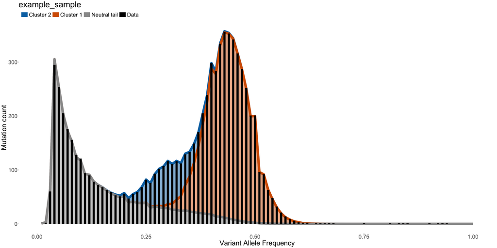

```r
sfs_file <- file.path(output_dir, paste0("DECODE_SFS_", sample_id))

DECODE_plot_SFS(
    DECODE_result = DECODE_result,
    filename = sfs_file,
    filetype = "png"
)
```

The PNG is saved to `DECODE_results/DECODE_SFS_example_sample.png` at 30 × 15 inches and 150 dpi.

## 6b. Model selection plot

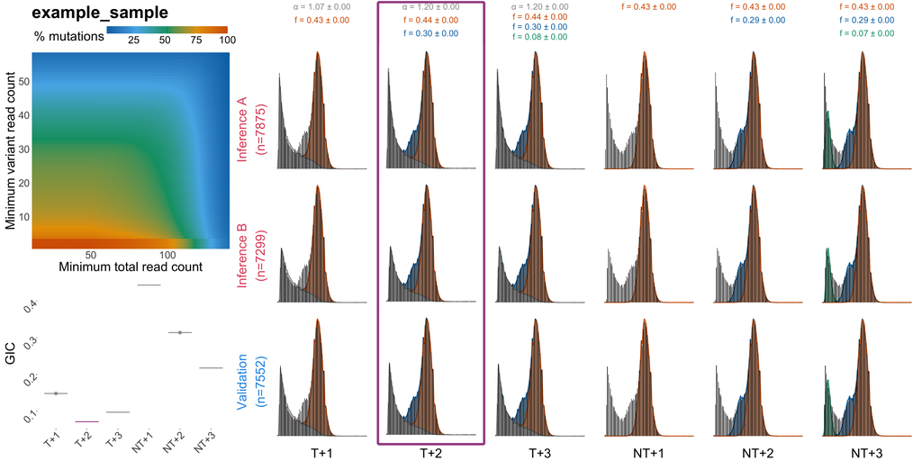

```r
model_selection_file <- file.path(
    output_dir,
    paste0("DECODE_model_selection_", sample_id)
)

DECODE_plot_model_selection(
    DECODE_result = DECODE_result,
    filename = model_selection_file,
    filetype = "png"
)
```

## 6c. Optional diagnostic plots

`DECODE_plot_criteria()` and `DECODE_plot_readcounts()` summarize model selection and the read-count filtering thresholds used by DECODE. They return ggplot objects and can be saved with `ggsave()` or displayed with `print()`.

```r
print(DECODE_plot_criteria(DECODE_result = DECODE_result))
print(DECODE_plot_readcounts(DECODE_result = DECODE_result))
```

# 7. Extract key parameters from DECODE results {#7-extract-key-parameters-from-decode-results}

After DECODE finishes, the selected model is stored in `DECODE_result`. The ABC-SMC-DRF algorithm returns a **posterior sample** of parameters in `best_fit$parameters` (one row per particle). In practice, each scalar parameter is summarized by its **posterior mean**.

## 7a. Retrieve the best fit

First locate the best-fitting model chosen by DECODE (with or without neutral tail, and the optimal cluster count):

```r
if (DECODE_result$best_with_tail) {
    fit_key <- "fits_with_tail"
} else {
    fit_key <- "fits_without_tail"
}

best_fit <- DECODE_result[[fit_key]]$all_fits[[
    paste0(DECODE_result$best_N_clusters, "_clusters")
]]
parameters <- best_fit$parameters

DECODE_result$best_with_tail
```

```
#> [1] TRUE
```

```r
DECODE_result$best_N_clusters
```

```
#> [1] 2
```

## 7b. Number of clusters

The selected number of mutation clusters is stored directly in the result object:

```r
N_clusters <- DECODE_result$best_N_clusters
N_clusters
```

```
#> [1] 2
```

## 7c. Purity and Cancer Cell Fraction (CCF) {#7c-purity-and-cancer-cell-fraction-ccf}

DECODE estimates a cluster frequency `Cluster_i_freq` (denoted `f` in the console report) for each cluster `i`. Under the **diploid assumption** used in this vignette (`nMajor = 1`, `nMinor = 1`), each cluster mutation lies on a single haploid copy, so for every diploid cluster

$$\mathrm{VAF} \approx \frac{\mathrm{CCF}_i}{2}$$

Equivalently, for cluster `i` we approximate

$$\mathrm{CCF}_i \approx \min\left(1,\ 2 \times \mathrm{mean}(\texttt{Cluster_i_freq})\right)$$

where `Cluster_i_freq` is the posterior sample of `f` for cluster `i`.

The cluster with the **highest** posterior mean `Cluster_i_freq` is interpreted as the descendant of the tumour **most recent common ancestor (MRCA)**. Its CCF equals the tumour cell fraction in the sample, i.e. **purity**:

$$\mathrm{purity} \approx \mathrm{CCF}_{i^*}, \quad i^* = \arg\max_i \mathrm{mean}(\texttt{Cluster_i_freq})$$

```r
cluster_mean_freq <- vapply(
    seq_len(N_clusters),
    function(i) mean(parameters[[paste0("Cluster_", i, "_freq")]]),
    numeric(1)
)
names(cluster_mean_freq) <- paste0("Cluster_", seq_len(N_clusters))

cluster_ccf <- pmin(1, 2 * cluster_mean_freq)
names(cluster_ccf) <- names(cluster_mean_freq)

mrca_cluster <- names(which.max(cluster_mean_freq))
purity <- cluster_ccf[mrca_cluster]

data.frame(
    cluster = names(cluster_mean_freq),
    mean_VAF = cluster_mean_freq,
    CCF = cluster_ccf
)
```

```
#>             cluster  mean_VAF       CCF
#> Cluster_1 Cluster_1 0.4351272 0.8702543
#> Cluster_2 Cluster_2 0.2996398 0.5992796
```

```r
purity
```

```
#> Cluster_1
#> 0.8702543
```

```r
mrca_cluster
```

```
#> [1] "Cluster_1"
```

The MRCA-descendant cluster is `mrca_cluster`; its CCF equals `purity`.

## 7d. Mutation burden per cluster {#7d-mutation-burden-per-cluster}

[output not shown]

For a **quick start**, we recommend summarizing mutation burden with the **inference A** counts:

```r
cluster_burden <- data.frame(
    cluster = paste0("Cluster_", seq_len(N_clusters)),
    Nmut_A = vapply(
        seq_len(N_clusters),
        function(i) mean(parameters[[paste0("Cluster_", i, "_Nmut_A")]]),
        numeric(1)
    ),
    Nmut_B = vapply(
        seq_len(N_clusters),
        function(i) mean(parameters[[paste0("Cluster_", i, "_Nmut_B")]]),
        numeric(1)
    ),
    Nmut_validation = vapply(
        seq_len(N_clusters),
        function(i) mean(parameters[[paste0("Cluster_", i, "_Nmut_validation")]]),
        numeric(1)
    ),
    CCF = cluster_ccf
)
cluster_burden
```

```
#>             cluster    Nmut_A    Nmut_B Nmut_validation       CCF
#> Cluster_1 Cluster_1 4251.5736 4251.5736       4251.5736 0.8702543
#> Cluster_2 Cluster_2  882.0707  882.0595        882.0684 0.5992796
```

If the selected model includes a neutral tail (`DECODE_result$best_with_tail == TRUE`), the tail mutation burden can be read similarly, for example `mean(parameters$Tail_Nmut_A)`.

## 7e. Summary table

Combine the key quantities into one table:

```r
decode_summary <- data.frame(
    sample_id = DECODE_result$sample_id,
    neutral_tail = DECODE_result$best_with_tail,
    N_clusters = N_clusters,
    purity = purity,
    mrca_cluster = mrca_cluster
)
decode_summary
```

```
#>                sample_id neutral_tail N_clusters    purity mrca_cluster
#> Cluster_1 example_sample         TRUE          2 0.8702543    Cluster_1
```

```r
cluster_burden[, c("cluster", "CCF", "Nmut_A")]
```

```
#>             cluster       CCF    Nmut_A
#> Cluster_1 Cluster_1 0.8702543 4251.5736
#> Cluster_2 Cluster_2 0.5992796  882.0707
```

# 8. Mutation assignment

DECODE fits the SFS at the **bulk** level. To associate individual mutations with the inferred neutral tail or mutation clusters, use `DECODE_mutation_assignment()` in `DECODE_analysis.r`.

This function requires a mutation table with a `normalized_VAF` column: the VAF each mutation would have if it occurred in a **diploid** locus, on a **single** mutant copy, in the same sample purity. Mutations can come from **any** copy-number background (not only `nMajor = 1`, `nMinor = 1`), as long as `normalized_VAF` is computed correctly.

## 8a. Normalized VAF

Let $f_i$ be the observed VAF of mutation $i$, with multiplicity $m_i$ and total copy number $c_i = \mathrm{major\_cn} + \mathrm{minor\_cn}$ in a sample with purity $\rho$. Following Tarabichi et al. (2021), the **normalized VAF** is the expected VAF if the mutation were diploid:

$$\bar{f}_i = f_i \cdot \frac{\dfrac{\rho}{2\rho + 2(1-\rho)}}{\dfrac{m_i \cdot \rho}{c_i \cdot \rho + 2(1-\rho)}}$$

For **diploid** mutations (`major_cn = 1`, `minor_cn = 1`, `multiplicity = 1`), this simplifies to $\bar{f}_i = f_i$.

Use the purity estimate from Section 7c as $\rho$.

```r
compute_normalized_vaf <- function(VAF, multiplicity, total_cn, purity) {
    vaf_if_diploid <- purity / (2 * purity + 2 * (1 - purity))
    vaf_expected <- (multiplicity * purity) / (total_cn * purity + 2 * (1 - purity))
    VAF * vaf_if_diploid / vaf_expected
}
```

## 8b. Mutation multiplicity

The normalized VAF formula requires the **multiplicity** $m_i$: the number of mutant copies of the alternate allele in the tumor cells.

When `major_cn <= 1`, only one mutant copy can be present on the major allele, so $m_i = 1$.

When `major_cn > 1`, multiple mutant copies are possible. We recommend estimating multiplicity with **[GRITIC](https://github.com/VanLoo-lab/gritic)**, which takes:

- a mutation table (`Chromosome`, `Position`, `Tumor_Ref_Count`, `Tumor_Alt_Count`),
- a copy-number table (`Chromosome`, `Segment_Start`, `Segment_End`, `Major_CN`, `Minor_CN`), and
- the sample purity $\rho$.

No further inputs are required. Install GRITIC with `pip install gritic` and run, for example:

```r
# Convert DECODE inputs to GRITIC format, then run (command-line example):
# python rungritic_cmd.py \
#   --mutation_table path/to/snv_table.tsv \
#   --copy_number_table path/to/cn_table.tsv \
#   --purity 0.87 \
#   --sample_id example_sample \
#   --output path/to/gritic_output
#
# GRITIC writes a processed mutation table with multiplicity probabilities
# (_mutation_table.tsv). Use the estimated multiplicity for each SNV.
```

In this vignette, the example file `mutation_table_with_multiplicity.csv` supplies multiplicity for all 100 SNVs (including loci with `major_cn > 1`). For your own data, run GRITIC and merge its multiplicity estimates into your annotated mutation table by `Chromosome` and `Position`.

## 8c. Build the mutation assignment table

The worked example below reads `mutation_table_with_multiplicity.csv` directly. It contains 100 SNVs with copy number and multiplicity already annotated (including non-diploid loci). For a full cohort, start from `mutation_table_cn` (Section 2), add a `multiplicity` column (`1` when `nMajor <= 1`; GRITIC otherwise), then compute `normalized_VAF`.

```r
mutation_assignment_input <- read.csv(
    file.path(data_dir, "mutation_table_with_multiplicity.csv")
)

mutation_assignment_input$VAF <- with(
    mutation_assignment_input,
    Alt_count / (Ref_count + Alt_count)
)
mutation_assignment_input$total_cn <- with(
    mutation_assignment_input,
    major_cn + minor_cn
)

# Recompute normalized VAF using purity from DECODE (Section 7)
mutation_assignment_input$normalized_VAF <- compute_normalized_vaf(
    VAF = mutation_assignment_input$VAF,
    multiplicity = mutation_assignment_input$multiplicity,
    total_cn = mutation_assignment_input$total_cn,
    purity = purity
)

head(
    mutation_assignment_input[
        ,
        c(
            "Chromosome", "Position", "Ref_count", "Alt_count",
            "major_cn", "minor_cn", "multiplicity", "VAF", "normalized_VAF"
        )
    ]
)
```

```
#>   Chromosome Position Ref_count Alt_count major_cn minor_cn multiplicity
#> 1       chr1  2328264        59        79        1        1            1
#> 2       chr1 17867697        76        43        1        1            1
#> 3       chr1 29467603       126        16        1        1            1
#> 4       chr1 52838561        63        49        1        1            1
#> 5       chr1 71929324        74        60        1        1            1
#> 6       chr1 97168848        58        36        1        1            1
#>         VAF normalized_VAF
#> 1 0.5724638      0.5724638
#> 2 0.3613445      0.3613445
#> 3 0.1126761      0.1126761
#> 4 0.4375000      0.4375000
#> 5 0.4477612      0.4477612
#> 6 0.3829787      0.3829787
```

For loci with `major_cn <= 1`, set `multiplicity <- 1`. For loci with `major_cn > 1`, populate `multiplicity` from GRITIC output before calling `compute_normalized_vaf()`.

## 8d. Soft assignment with `DECODE_mutation_assignment()`

`DECODE_mutation_assignment()` maps each mutation to the VAF bin of its `normalized_VAF` in the fitted SFS, then reads off the **component proportions** in that bin. This yields a soft assignment: columns `prob_tail`, `prob_cluster_1`, `prob_cluster_2`, … give the probability that each mutation belongs to each DECODE component.

By default the function uses the **best overall fit** (`neutral_tail = NA`, `N_clusters = NULL`) and the **inference A** SFS (`mode = "inference_A"`). Other modes (`inference_B`, `validation`) can be selected to match the mutation subset used in Section 7d.

```r
mutation_assignment <- DECODE_mutation_assignment(
    DECODE_result = DECODE_result,
    mutation_table = mutation_assignment_input,
    mode = "inference_A"
)
```

```
#>
#> Assign mutations to DECODE components with configuration with tail + 2 clusters...
```

```r
prob_cols <- grep("^prob_", names(mutation_assignment), value = TRUE)
head(mutation_assignment[, c("Chromosome", "Position", "normalized_VAF", prob_cols)])
```

```
#>   Chromosome Position normalized_VAF   prob_tail prob_cluster_1 prob_cluster_2
#> 1       chr1  2328264      0.5724638 0.006007407   9.939147e-01   7.791488e-05
#> 2       chr1 17867697      0.3613445 0.119953406   7.251806e-01   1.548660e-01
#> 3       chr1 29467603      0.1126761 0.999616175   6.780449e-07   3.831470e-04
#> 4       chr1 52838561      0.4375000 0.027318747   9.686984e-01   3.982896e-03
#> 5       chr1 71929324      0.4477612 0.023104419   9.744938e-01   2.401830e-03
#> 6       chr1 97168848      0.3829787 0.076400329   8.665217e-01   5.707796e-02
```

Each row’s probability columns sum to 1 (when the mutation falls inside a valid SFS bin). For example, a mutation with high `prob_cluster_1` and low `prob_tail` is likely assigned to cluster 1 rather than the neutral tail.

Save the full assignment table:

```r
assignment_file <- file.path(output_dir, paste0("mutation_assignment_", sample_id, ".csv"))
write.csv(mutation_assignment, file = assignment_file, row.names = FALSE)
assignment_file
```

```
#> [1] "./DECODE_results/mutation_assignment_example_sample.csv"
```

# Summary

This workflow covered the standard DECODE analysis path (Sections 1–8):

1. **Section 1** — Load a mutation table and copy-number segments.
2. **Section 2** — Annotate each mutation with copy number via `findInterval`.
3. **Sections 3–4** — Filter to diploid loci and run `DECODE()`.
4. **Section 5** — Save the result with `saveRDS()`.
5. **Section 6** — Generate SFS and model-selection plots.
6. **Section 7** — Extract number of clusters, purity, CCF, and mutation burden.
7. **Section 8** — Compute `normalized_VAF`, estimate multiplicity with GRITIC, and assign mutations with `DECODE_mutation_assignment()`.

For your own data, replace the paths in `data_dir` with your mutation table and copy-number segment files, then repeat the same steps.